# Yelp Open Dataset: Exploratory Data Analysis

Jerry Luo

2026-05-08

## 1. Introduction

### 1.2 Dataset Format

The dataset is distributed as six JSON files:

| File | Contents |
| --- | --- |
| `business.json` | Location, attributes, categories, hours |
| `review.json` | Full review text, ratings, and vote counts |
| `user.json` | Profiles, social graph, compliments |
| `checkin.json` | Checkins on a business |
| `tip.json` | Tips written by a user on a business |
| `photo.json` | Not used |

JSON is not suitable for data analysis, as the files must be fully parsed before any processing.

### 1.3 Conversion to SQLite

The dataset was pre-processed via a Python script that reads each JSON file and inserts scalar fields into a SQLite database. Fields whose values are JSON objects or arrays were dropped or converted into comma separated list.

SQLite was chosen because: - Memory usage is significantly reduced. - Querys are usually faster.

## 2. Setup

```r
library(RSQLite)
library(tidyverse)
library(scales)
library(usmap)

con <- dbConnect(RSQLite::SQLite(), "yelp_dataset/yelp.db")
dbListTables(con)
```

```
## [1] "business" "checkin"  "review"   "tip"      "user"
```

## 3. Dataset Size

```
##      Table     Row
## 1 business  150346
## 2  checkin  131930
## 3   review 6990280
## 4      tip  908915
## 5     user 1987897
```

## 4. Business

### 4.1 Summary Statistics

```
##   total_businesses open_count closed_count mean_stars mean_review_count max_review_count
## 1           150346     119698        30648      3.597              44.9             7568
##   distinct_states distinct_cities
## 1              27            1416
```

### 4.2 Open vs. Closed

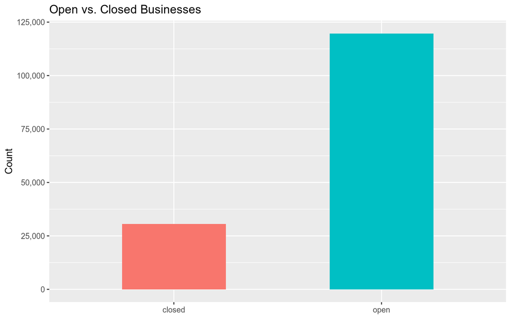

### 4.3 Star Rating Distribution

Star ratings are rounded to the nearest half-star in the dataset.

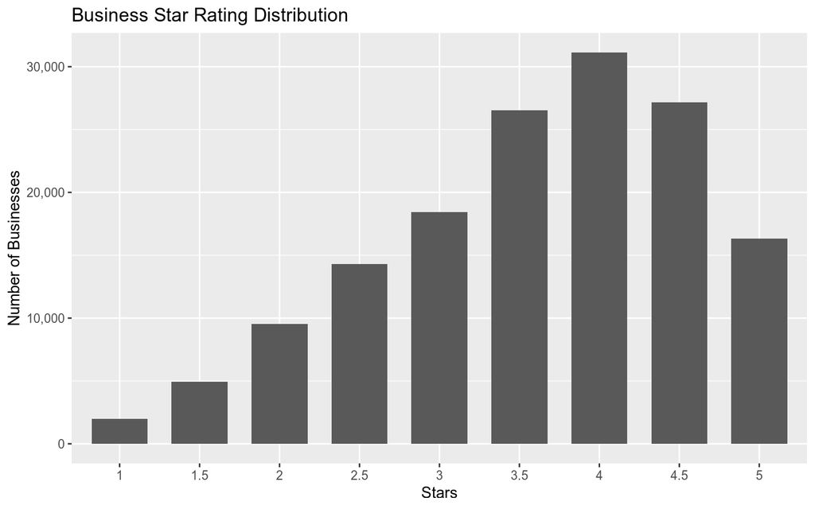

### 4.4 Top 10 States

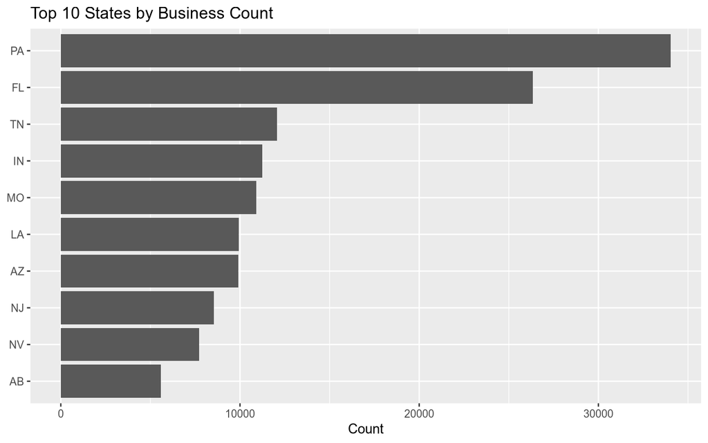

### 4.5 Top 10 Cities

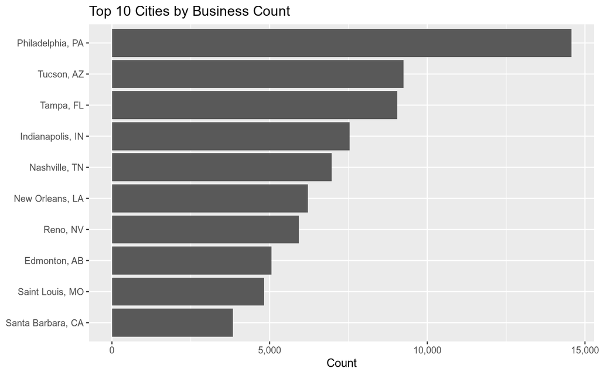

### 4.6 Review Count Distribution

Heavily right-skewed

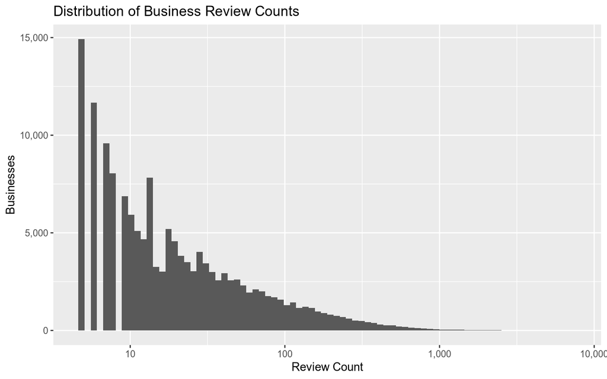

## 5. Reviews

### 5.1 Summary Statistics

```
##   total_reviews mean_stars total_useful_votes max_useful_votes total_funny_votes
## 1       6990280      3.749            8280748             1182           2282743
##   max_funny_votes total_cool_votes max_cool_votes     earliest_review       latest_review
## 1             792          3485476            404 2005-02-16 03:23:22 2022-01-19 19:48:45
```

### 5.2 Star Rating Distribution

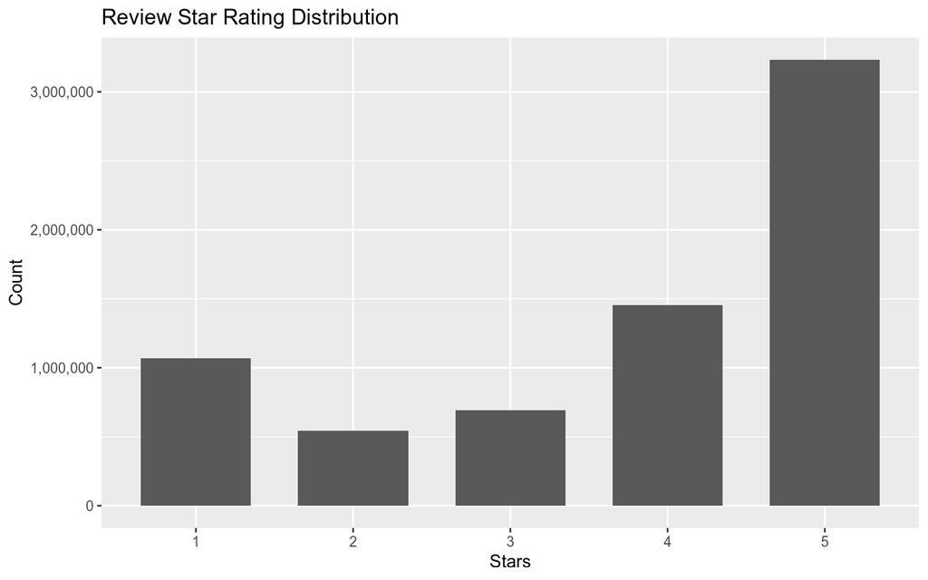

### 5.3 Review Volume Over Time

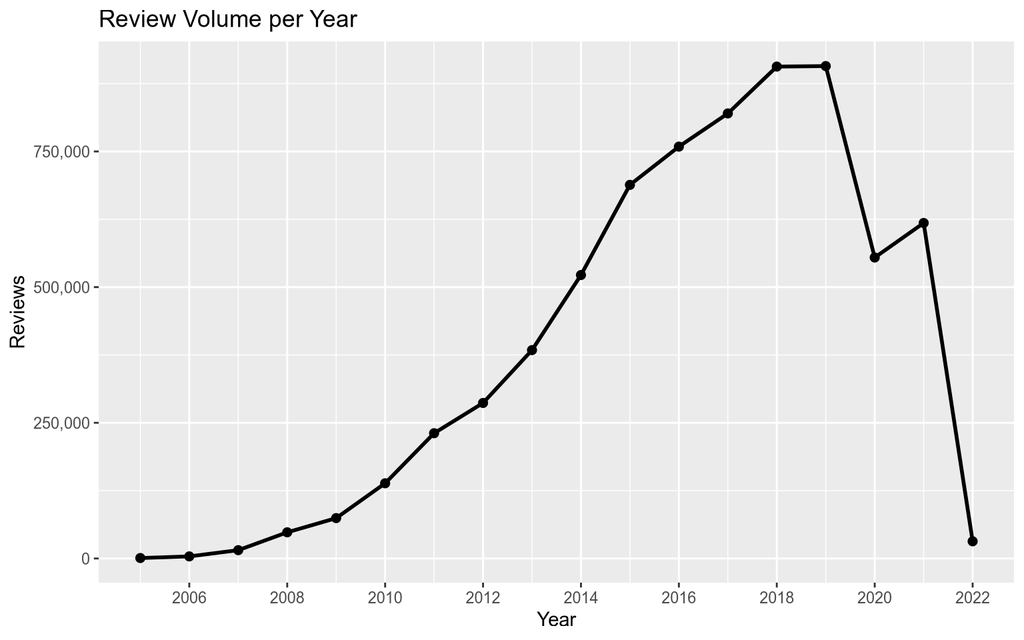

### 5.4 Vote Bucketing

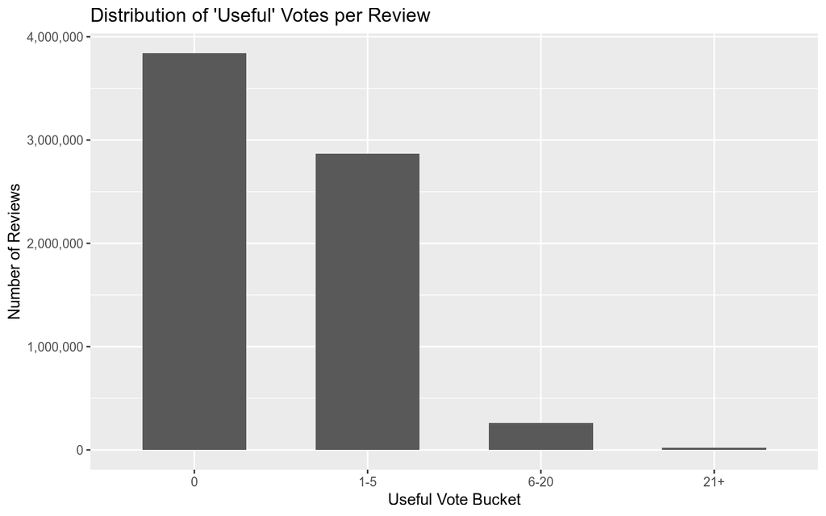

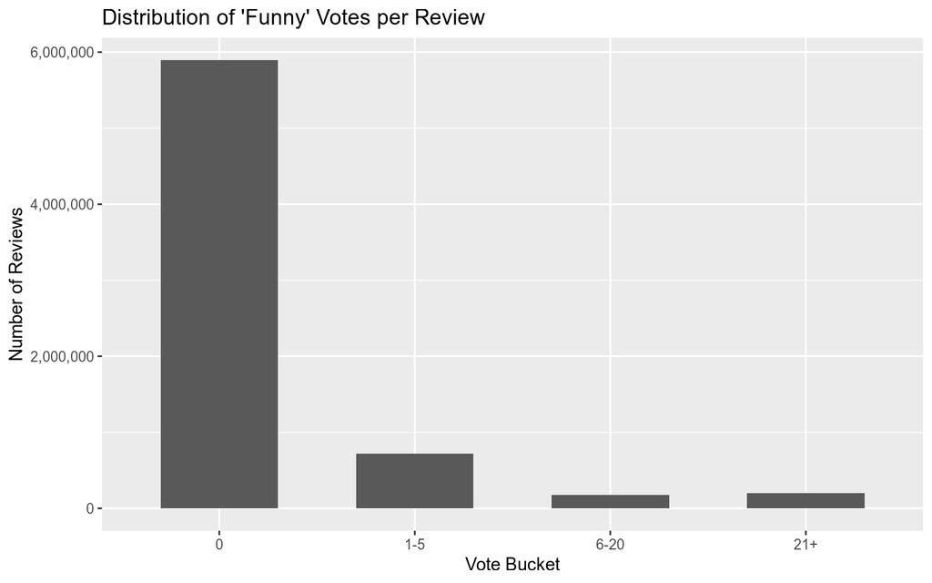

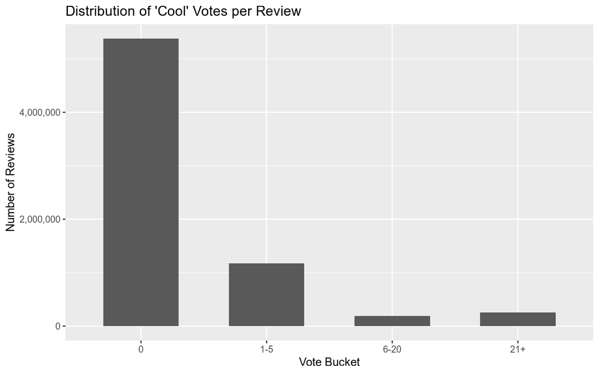

## 6. Users

### 6.1 Summary Statistics

```
##   total_users mean_reviews max_reviews mean_fans max_fans mean_avg_stars
## 1     1987897         23.4       17473      1.47    12497           3.63
##       earliest_member       latest_member
## 1 2004-10-12 08:46:11 2022-01-19 17:15:47
```

### 6.2 Review Count Distribution

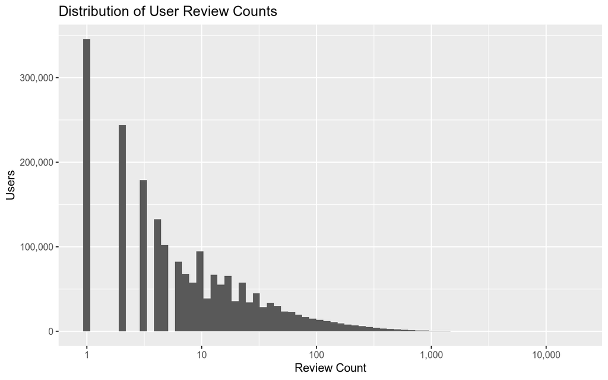

### 6.3 New User Registrations per Year

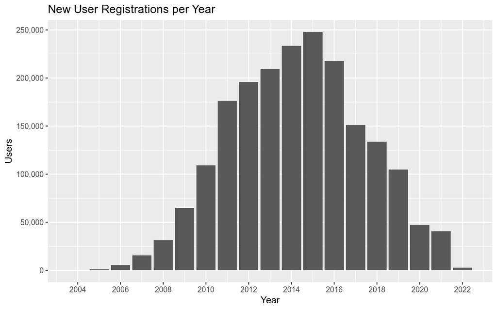

### 6.4 Distribution of Average Star Rating Given by Users

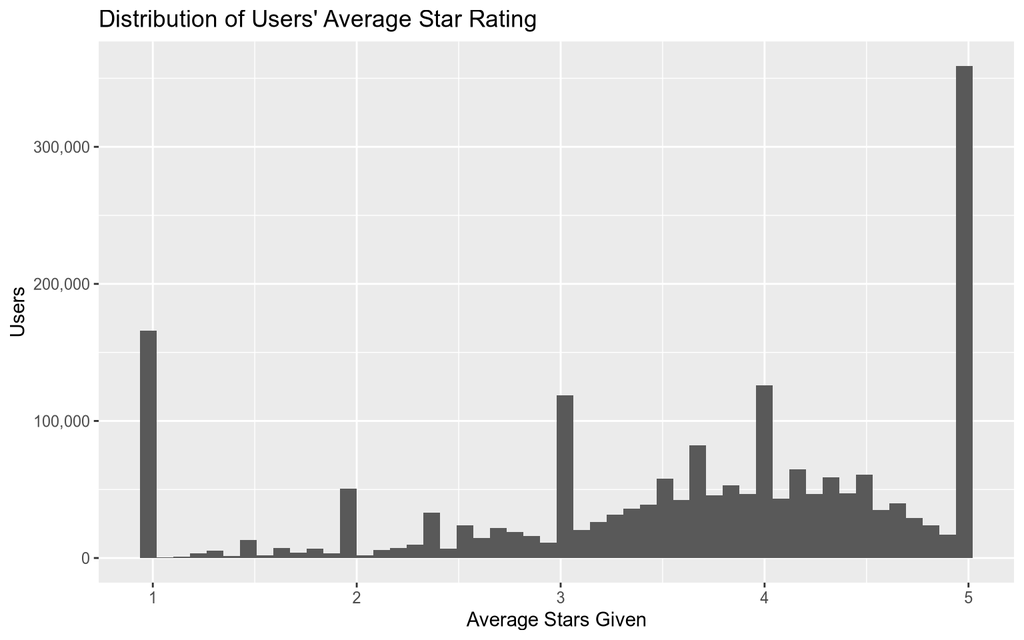

### 6.5 Fan Count Distribution

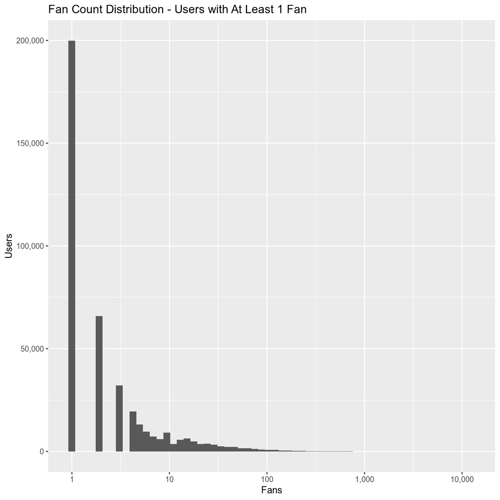

## 7. Tips

### 7.1 Summary Statistics

```
##   total_tips mean_compliments max_compliments tips_with_compliments        earliest_tip
## 1     908915            0.013               6                 10539 2009-04-16 13:11:49
##            latest_tip
## 1 2022-01-19 20:38:55
```

### 7.2 Tip Volume Over Time

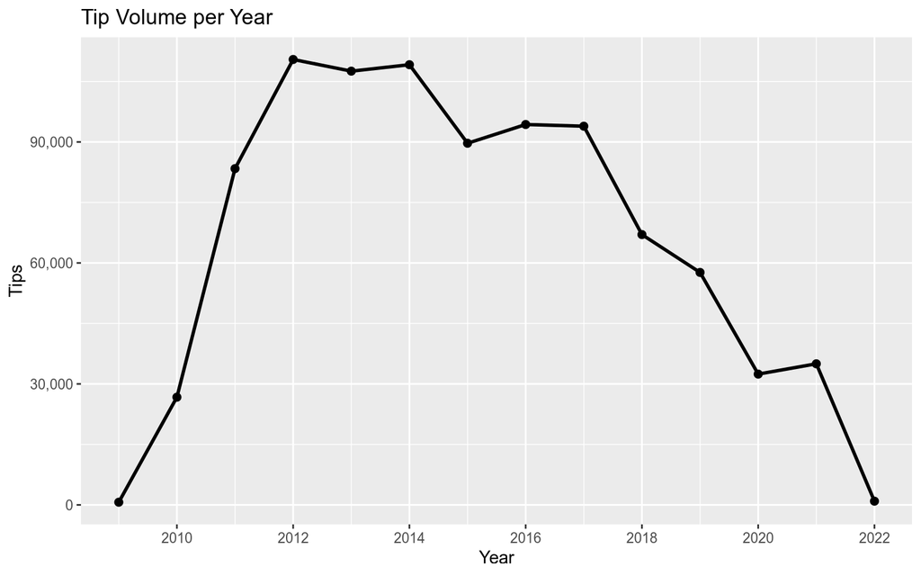

## 8. Reviewer Rudeness by State

We can investigate how rude the users are in a given states by checking how often a one-star review is given.

### 8.1 Summary by States

```
##    state total_reviews n_businesses one_star_n one_star_rate mean_stars
## 1     IL         51832         2145      10556        0.2037     3.5121
## 2     DE         70302         2265      14074        0.2002     3.5068
## 3     NJ        260897         8536      51506        0.1974     3.5571
## 4     NV        430678         7715      76978        0.1787     3.7251
## 5     AZ        431708         9912      75214        0.1742     3.6944
## 6     ID        157572         4467      26137        0.1659     3.7601
## 7     FL       1161545        26330     189588        0.1632     3.7618
## 8     TN        614388        12056      92871        0.1512     3.7604
## 9     PA       1598960        34039     241130        0.1508     3.6988
## 10    MO        502385        10913      75066        0.1494     3.7341
## 11    AB        109436         5573      16212        0.1481     3.5689
## 12    IN        489752        11247      68970        0.1408     3.7893
## 13    CA        348856         5203      42849        0.1228     3.9600
## 14    LA        761673         9924      88302        0.1159     3.8815
```

### 8.2 One-Star Review Rate

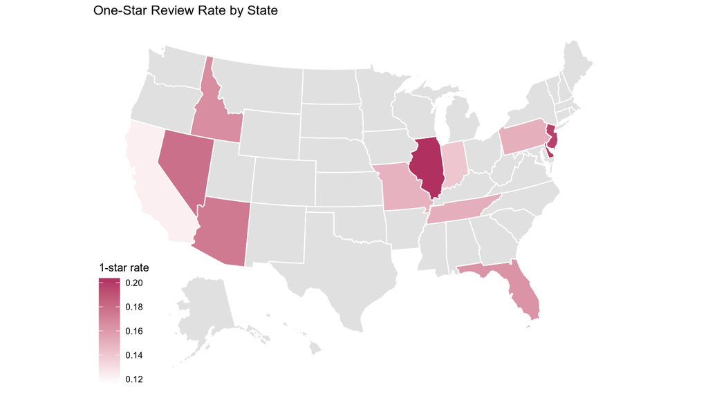

### 8.3 Mean Star Rating

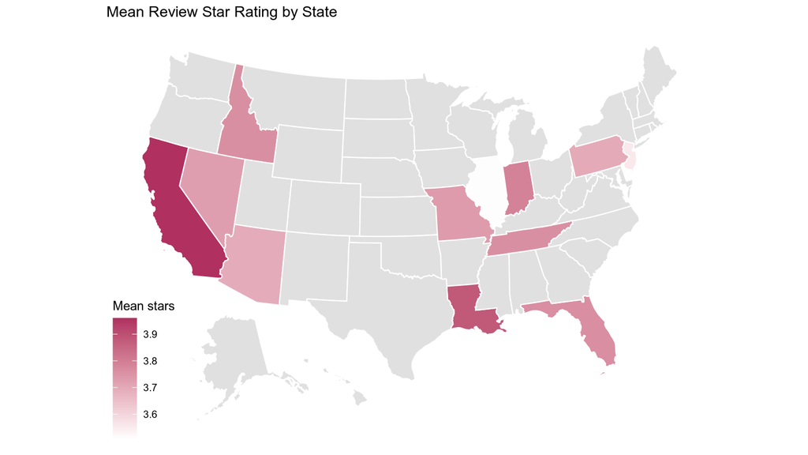

### 8.4 One-Star Rate by States

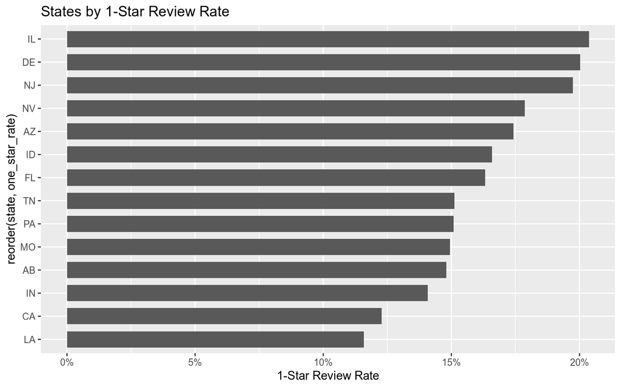

### 8.5 Conclusion

The one-star rates do differ from state to state, though not by a lot. Illinois has the highest one-star rate. This can suggest that the residents are more critical commenter, or service quality are poorer.

### 8.6 Limitation

- Reviews from bots are accounted.
- Limited coverage in the states. Mostly concentrated in some metro areas.
- Other factors influence rating decisions.